# Introduction

[Gnuplot](http://www.gnuplot.info/) is a venerable (but actively developed), very powerful and fast program for plotting. [Julia](https://julialang.org) is a very powerful language for numerical computing. [Gaston](https://github.com/mbaz/Gaston.jl) is a package for plotting Julia data and functions using gnuplot.

The following diagram illustrates how Gaston works. On the left there is a gnuplot script; the equivalent Gaston function call is on the right.

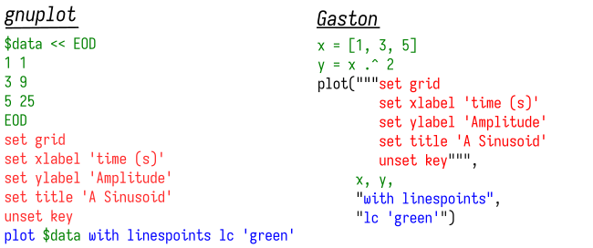

The data to plot is in green color. In gnuplot, the data can be provided inline as a *data block* (as in this example), or it can be provided in a separate file. Gaston can plot data stored in arrays (`x` and `y` in this example). Gaston also supports recipes to plot arbitrary Julia types.

The lines in red specify the *axes settings*, affecting things like the presence of a grid, the title, the legend box, tics positions/labels, etc. Finally, in blue color, the *plot settings* or *plotline* specify the properties of one specific curve within the axes (for example, the line color, thickness and style, which marker to use, etc.)

There is a close correspondence between gnuplot and Gaston commands; in fact, the main purpose of Gaston is to translate the Julia code on the right to the gnuplot commands on the left. Gaston has two main features:

- It provides convenient, flexible syntax for plotting, along with common 2-D and 3-D plot styles.
- It provides a simple mechanism to add user-defined recipes for plotting arbitrary Julia types.

Other features are:

- Support for plotting in separate GUI windows, in the terminal (with text or [sixels](https://en.wikipedia.org/wiki/Sixel)), in VS Code, or in notebooks (such as Jupyter and Pluto).
- Handling multiple co-existing interactive GUI plot windows.
- Support for (user-defined) themes.
- Convenient commands for common types of plots (like histograms, contour plots, surface plots, heatmaps, etcetera).
- Convenient syntax for creating multiplots and animations.
- Saving plots to multiple formats, including pdf, png and svg.
- Integrated color palettes from ColorSchemes.jl.

**Note**

This manual is for Gaston version 2. The manual for Gaston v1 (no longer maintained) is [here](https://mbaz.github.io/Gaston.jl/v1/index.html).

## Learning gnuplot

This documentation assumes at least a basic understanding of gnuplot. Some pointers to get started with gnuplot are:

- The [official documentation](http://www.gnuplot.info/documentation.html).
- The [official list of tutorials](http://www.gnuplot.info/help.html).
- [Plotting data](http://www.gnuplotting.org/plotting-data/) article on [gnuplotting.org](http://www.gnuplotting.org/).
- [A blog post about Gaston by Julia Frank](https://juliaifrank.com/gnuplot-with-julia-for-beautiful-graphics/).
- Stackoverflow has a [gnuplot tag](https://stackoverflow.com/questions/tagged/gnuplot) with answers to more than 6,500 questions.

The following are interesting plot galleries:

- [Official gnuplot demo gallery](http://www.gnuplot.info/screenshots/index.html#demos).
- [Wikimedia commons gallery](https://commons.wikimedia.org/wiki/Category:Gnuplot_diagrams).
- [Nice collection of volumetric plots](https://ayapin-film.sakura.ne.jp/Gnuplot/pm3d.html).

## Installation

Gaston v2.x requires Julia version 1.8.0 or above (Gaston v1.x supports Julia 1.6 and above), and has been tested with gnuplot versions 5 and 6. You should manually install gnuplot on your system prior to using Gaston. On Linux, it is highly recommended that you select a version with Qt support: on Debian and Ubuntu, you will need `gnuplot-qt`. On Arch and its derivatives, a simple `pacman -S gnuplot` suffices.

Gnuplot also supports Windows and Mac. This author does not use these systems much, but it is said that gnuplot Windows executables are available at [Sourceforge’s gnuplot repository](https://sourceforge.net/projects/gnuplot/files/gnuplot/). On Mac, gnuplot is supposed to be available using Homebrew.

To install Gaston from the Julia REPL, run

```julia
julia> ]add Gaston
```

Typing `]` switches the Julia REPL to the package manager, and the `add` command installs the package. To exit the package manager, hit the backspace key. Load Gaston into your Julia session with

```julia
using Gaston
```

**Specifying the location of gnuplot**

```
The location of the gnuplot executable can be specified with the environmental variable
`JULIA_GNUPLOT_EXE`. If gnuplot is in the system's path, setting this variable is not
necessary.
```

## Support

Here are some ideas on what to do if you need help with Gaston:

- Post a question in [Julia’s discuss forum](https://discourse.julialang.org/tag/plotting) in the “plotting” category.
- Chat with the author (@mbaz) on [Julia’s Zulip chat forum](https://julialang.zulipchat.com/), in the “plotting” or “helpdesk” channels.
- Bug reports, suggestions and pull requests are welcome at [Gaston’s github page](https://github.com/mbaz/Gaston.jl).

## Contributing

Contributions are welcome! Examples of things you can do are bug reports, improvements to the documentation, new examples and tutorials, and new features or suggestions.

## Gnuplot startup file

Gnuplot reads and executes a startup file, if it exists, before every plot. Since an un-configured gnuplot produces plots that are less than attractive, the following minimum configuration is suggested (and was used to generate the plots in this document):

```
set linetype 1 lc rgb "blue" pt 3 ps 1.2
set linetype 2 lc rgb "red" pt 4 ps 1.2
set linetype 3 lc rgb "dark-green" pt 6 ps 1.2
set linetype 4 lc rgb "orange-red" pt 12 ps 1.2
set linetype 5 lc rgb "gold" pt 5 ps 1.2
set linetype 6 lc rgb "dark-violet" pt 1 ps 1.2
set linetype 7 lc rgb "gray50" pt 2 ps 1.2
set linetype 8 lc rgb "black" pt 7 ps 1.2
set linetype cycle 8
set style data lines
set key noautotitle
set auto fix
set offsets graph .05, graph .05, graph .05, graph .05
```

The configuration file is `~/.gnuplot` on Unix-like systems, and `%APPDATA%\GNUPLOT.INI` on Windows.

## Next steps

- Read the Tutorial.
- See plot examples in the Examples section.
- Learn how to extend Gaston to plot arbitrary Julia types in the Recipes section.
- Learn all the details about how to plot with Gaston in the Manual.
- For specific information about migrating from Gaston v1 to v2, see the Migration Guide.
- Consult the full API Reference.

Gaston’s documentation includes three [Pluto](https://plutojl.org/) notebooks:

- An overview of the [essential plotting concepts](https://github.com/mbaz/Gaston.jl/tree/master/docs/v2/tutorial-essentials.jl).
- An overview of [3-D plotting](https://github.com/mbaz/Gaston.jl/tree/master/docs/v2/tutorial-3d.jl).
- A tutorial on how to [plot a torus](https://github.com/mbaz/Gaston.jl/tree/master/docs/how-to-plot-a-torus.jl) (which aims to showcase Gaston in interactive notebooks).

## Acknowledgments

When developing Gaston, I’ve been inspired by the excellent features and ideas behind other Julia plotting packages, including Plots.jl, Gnuplot.jl, PGFPlotsX.jl, and Makie.jl. Many thanks to their multiple authors for freely sharing their code and their APIs!